# Predicting Diamond Prices

Phanindra Reddigari  
8/16/2015

### Objectives:

Analyze the well known diamond dataset and develop a Shiny application for robust regression model for predicting diamond prices on test dataset. The UI is tab structured to provide user interaction to navigate the different analysis phases back and forth with relative ease:

- Tab1: User Documentation
- Tab2: Basic data exploration using ggplots of price vs other variables
- Tab3 and Tab4: Price density plots and data summary table
- Tab5: Summary of RF Regression (price ~ .) on training partition
- Tab6: Predict prices on test partition
- Tab7 and Tab8: Plots for documented RF Regression

### UI Navigation Overview

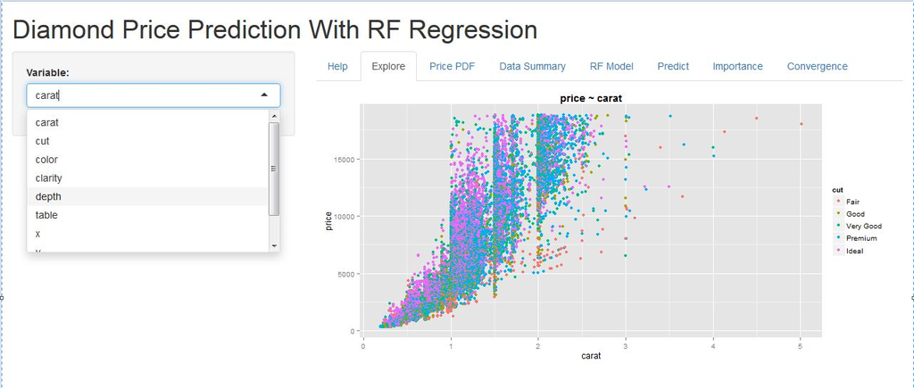

The UI screenshot demonstrates the user interaction aspects of the Shiny application

### RF Regression Outcome

The UI tab designated RF Regression presents the overall results for RF Regression for diamond data set

```
  mtry      RMSE  Rsquared   RMSESD RsquaredSD
1    2 1093.2661 0.9341887 107.7058 0.01181468
2   12  887.4285 0.9481134 116.3227 0.01288844
3   23  900.0651 0.9465774 116.7550 0.01331971
```